# Regression Models - Quiz 3

Fenton Taylor

September 1, 2016

```r
data(mtcars)
library(dplyr)
```

### Question 1

Consider the mtcars data set. Fit a model with mpg as the outcome that includes number of cylinders as a factor variable and weight as confounder. Give the adjusted estimate for the expected change in mpg comparing 8 cylinders to 4.

```r
mtcars <- mutate(mtcars, cyl=factor(cyl))
fit1 <- lm(mpg ~ cyl + wt, mtcars)
sf1 <- summary(fit1)$coef
sf1
```

```
##             Estimate Std. Error t value Pr(>|t|)
## (Intercept)    33.99      1.888   18.01 6.26e-17
## cyl6           -4.26      1.386   -3.07 4.72e-03
## cyl8           -6.07      1.652   -3.67 9.99e-04
## wt             -3.21      0.754   -4.25 2.13e-04
```

#### Answer

-6.071

Compared to 4-cyl cars with a mean of 33.991 mpg, 8-cyl cars have a mean mpg -6.071 less at 27.92 mpg.

### Question 2

Consider the mtcars data set. Fit a model with mpg as the outcome that includes number of cylinders as a factor variable and weight as a possible confounding variable. Compare the effect of 8 versus 4 cylinders on mpg for the adjusted and unadjusted by weight models. Here, adjusted means including the weight variable as a term in the regression model and unadjusted means the model without weight included. What can be said about the effect comparing 8 and 4 cylinders after looking at models with and without weight included?.

```r
fit2 <- lm(mpg ~ cyl, mtcars)
sf2 <- summary(fit2)$coef
compare <- data.frame(with_wt=sf1[3],without_wt=sf2[3], row.names = "8-cyl Est.")
compare
```

```
##            with_wt without_wt
## 8-cyl Est.   -6.07      -11.6
```

#### Answer

Therefore, holding weight constant, cylinder appears to have less of an impact on mpg than if weight is disregarded.

### Question 3

Consider the mtcars data set. Fit a model with mpg as the outcome that considers number of cylinders as a factor variable and weight as confounder. Now fit a second model with mpg as the outcome model that considers the interaction between number of cylinders (as a factor variable) and weight. Give the P-value for the likelihood ratio test comparing the two models and suggest a model using 0.05 as a type I error rate significance benchmark.

```r
library(lmtest)
fit3 <- lm(mpg ~ cyl*wt, mtcars)
test <- lrtest(fit1,fit3)
pval <- test$`Pr(>Chisq)`[2]
test
```

```
## Likelihood ratio test
##
## Model 1: mpg ~ cyl + wt
## Model 2: mpg ~ cyl * wt
##   #Df LogLik Df Chisq Pr(>Chisq)
## 1   5  -73.3
## 2   7  -70.7  2  5.14      0.076 .
## ---
## Signif. codes:  0 '***' 0.001 '**' 0.01 '*' 0.05 '.' 0.1 ' ' 1
```

#### Answer

The P-value 0.076 is larger than 0.05. So, according to our criterion, we would fail to reject, which suggests that the interaction terms may not be necessary.

### Question 4

Consider the mtcars data set. Fit a model with mpg as the outcome that includes number of cylinders as a factor variable and weight inlcuded in the model as lm(mpg ~ I(wt * 0.5) + factor(cyl), data = mtcars). How is the wt coefficient interpretted?

```r
fit4 <- lm(mpg ~ I(wt * 0.5) + cyl, mtcars)
summary(fit4)$coef
```

```
##             Estimate Std. Error t value Pr(>|t|)
## (Intercept)    33.99       1.89   18.01 6.26e-17
## I(wt * 0.5)    -6.41       1.51   -4.25 2.13e-04
## cyl6           -4.26       1.39   -3.07 4.72e-03
## cyl8           -6.07       1.65   -3.67 9.99e-04
```

```r
compare <- data.frame(per_half_ton=sf1[4], per_ton=summary(fit4)$coef[2],
                      row.names = "wt coef")
compare
```

```
##         per_half_ton per_ton
## wt coef        -3.21   -6.41
```

#### Answer

One unit of the weight variable equals 1000 lbs. Multiplying wt*0.5 doubles the coeffiecient, which corresponds to the estimated expected change in MPG per one ton increase in weight for a specific number of cylinders (4, 6, 8).

### Question 5

Consider the following data set:

x <- c(0.586, 0.166, -0.042, -0.614, 11.72)  
y <- c(0.549, -0.026, -0.127, -0.751, 1.344)

Give the hat diagonal for the most influential point.

```r
x <- c(0.586, 0.166, -0.042, -0.614, 11.72)
y <- c(0.549, -0.026, -0.127, -0.751, 1.344)

fit5 <- lm(y ~ x)
hatvalues(fit5)
```

```
##     1     2     3     4     5
## 0.229 0.244 0.253 0.280 0.995
```

```r
max_hat <- hatvalues(fit5)[which.max(hatvalues(fit5))]
max_hat
```

```
##     5
## 0.995
```

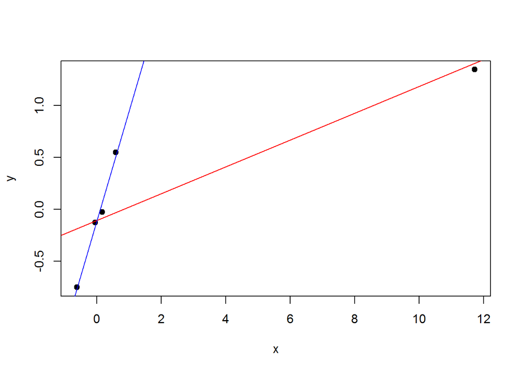

```r
# So, the 5th row contains the data for the most influential point.
# Let's plot the data and take a look at the regression line with the extreme
# data point (red line) and without it (blue line)

plot(x, y, pch=19)
abline(fit5, col="red")
fit6 <- lm(y[-which.max(hatvalues(fit5))] ~ x[-which.max(hatvalues(fit5))])
abline(fit6, col="blue")
```

#### Answer

The hat value for the most influential point is 0.995.

### Question 6

Consider the following data set:

x <- c(0.586, 0.166, -0.042, -0.614, 11.72)  
y <- c(0.549, -0.026, -0.127, -0.751, 1.344)

Give the slope dfbeta for the point with the highest hat value.

```r
x <- c(0.586, 0.166, -0.042, -0.614, 11.72)
y <- c(0.549, -0.026, -0.127, -0.751, 1.344)

fit5 <- lm(y ~ x)
im <- influence.measures(fit5)$infmat
im
```

```
##    dfb.1_     dfb.x     dffit cov.r   cook.d   hat
## 1  1.0621 -3.78e-01    1.0679 0.341 2.93e-01 0.229
## 2  0.0675 -2.86e-02    0.0675 2.934 3.39e-03 0.244
## 3 -0.0174  7.92e-03   -0.0174 3.007 2.26e-04 0.253
## 4 -1.2496  6.73e-01   -1.2557 0.342 3.91e-01 0.280
## 5  0.2043 -1.34e+02 -149.7204 0.107 2.70e+02 0.995
```

```r
max_beta <- im[which.max(abs(im[,"hat"])),"dfb.x"]
```

#### Answer

```r
max_beta
```

```
## [1] -134
```

### Question 7

Consider a regression relationship between Y and X with and without adjustment for a third variable Z. Which of the following is true about comparing the regression coefficient between Y and X with and without adjustment for Z.

```r
x <- c(0.586, 0.166, -0.042, -0.614, 11.72)
y <- c(0.549, -0.026, -0.127, -0.751, 1.344)
set.seed(4567)
z <- rnorm(5)

fit <- lm(y ~ x)
fitz <- lm(y ~ x + z)

summary(fit)$coef
```

```
##             Estimate Std. Error t value Pr(>|t|)
## (Intercept)   -0.107     0.2354  -0.453   0.6811
## x              0.129     0.0448   2.877   0.0637
```

```r
summary(fitz)$coef
```

```
##             Estimate Std. Error t value Pr(>|t|)
## (Intercept)   -0.190     0.1736   -1.09   0.3883
## x              0.188     0.0438    4.28   0.0504
## z             -0.479     0.2437   -1.97   0.1881
```

#### Answer

It is possible for the coefficient to reverse sign after adjustment. For example, it can be strongly significant and positive before adjustment and strongly significant and negative after adjustment.